# Data Lab 11

Anin Nair

17-11-2023

### 1. Setting up the libraries and datsets

```r
library (tidyverse)
```

```r
library(ggplot2)
library(ggrepel)
library(gridExtra)
data <- read.csv("CIRI_data.csv")
data
```

| CTRY | YEAR | PHYSINT | polity2 |
| --- | --- | --- | --- |
| Afghanistan | 1981 | 0 | NA |
| Afghanistan | 1982 | 0 | NA |
| Afghanistan | 1983 | 0 | NA |
| Afghanistan | 1984 | 0 | NA |
| Afghanistan | 1985 | 0 | NA |
| Afghanistan | 1986 | 0 | NA |
| Afghanistan | 1987 | 0 | NA |
| Afghanistan | 1988 | 0 | NA |
| Afghanistan | 1989 | 0 | -8 |
| Afghanistan | 1990 | 0 | -8 |

[output cut: 6252 more lines]

## Part 1. Time Trend

Subsetting the data just for the El Salvador, India, Pakistan and Brazil from the entire csv file using the *subset* function. I selected the other countries based on personal interest and wanting to see how they compared to El Salvador. I had no other motives for the selection. It seems like the human rights score increased after the civil war which is indicated on the plot with a red line. They also have a higher human rights score than other countries after their civil war. I differentiated the countries using color as they looked aesthetically the best.

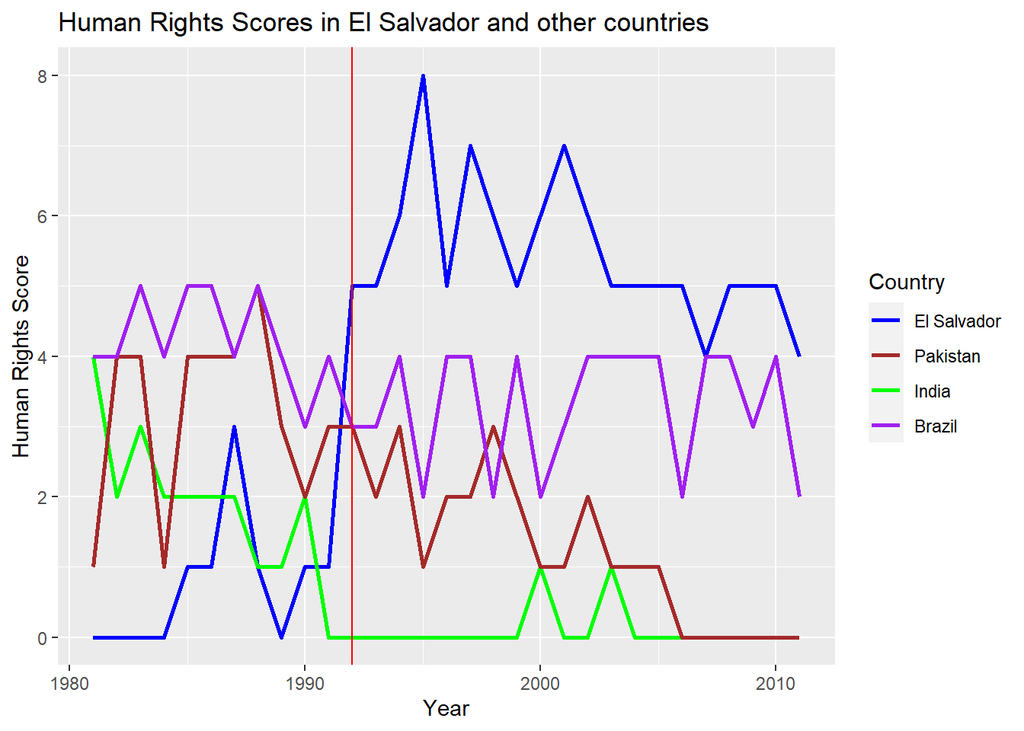

```r
ES <- subset(data, CTRY == "El Salvador")
ind <- subset(data, CTRY == "India")
pak <- subset(data, CTRY == "Pakistan")
br <- subset(data, CTRY == "Brazil")

p1 <- ggplot(data = ES, mapping = aes(x = YEAR, y = PHYSINT, color = "blue")) + geom_line(size = 1) + geom_line(data = ind, mapping = aes(color = "green"), size = 1)+ geom_line(data = pak, mapping = aes(color = "brown"), size = 1)+ geom_line(data = br, mapping = aes(color = "purple"), size = 1)   + geom_vline(data = , xintercept = 1992, color = "red ") + labs(x = "Year", y = "Human Rights Score") + ggtitle("Human Rights Scores in El Salvador and other countries") + scale_color_manual(name = "Country", labels= c("El Salvador", "Pakistan", "India", "Brazil"), values = c("blue", "brown", "green", "purple"))
p1
```

## Part 2. Scatter Plots

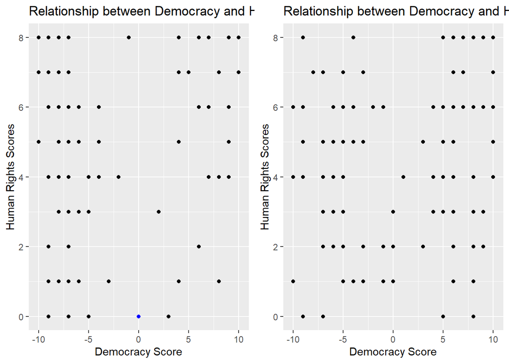

```r
year1981 <- subset(data, YEAR == 1981)
year1992 <- subset(data, YEAR == 1992)
year1981$el_sal <- rep('black', nrow(year1981))
year1981$el_sal[year1981$CTRY == 'El Salvador'] <- 'blue'
#any(year1992 == "El Salvador")
year1992$el_sal2 <- rep('black', nrow(year1992))
year1992$el_sal2[year1992$CTRY == 'El Salvador'] <- 'blue'
require(gridExtra)
p2 <- ggplot(data = year1981, mapping = aes(x = polity2, y = PHYSINT)) + geom_point(color = year1981$el_sal) + labs(x = "Democracy Score", y = "Human Rights Scores") + ggtitle("Relationship between Democracy and Human Rights Scores in 1981")


p3 <- ggplot(data = year1992, mapping = aes(x = polity2, y = PHYSINT)) + geom_point(color = year1992$el_sal2) + labs(x = "Democracy Score", y = "Human Rights Scores") + ggtitle("Relationship between Democracy and Human Rights Scores in 1992")
grid.arrange(p2, p3, ncol=2)
```